# Practical Machine Learning: Barbell Lifts

Hector Mario Romer

2022-03-27

## Background

Using devices such as Jawbone Up, Nike FuelBand, and Fitbit it is now possible to collect a large amount of data about personal activity relatively inexpensively. These type of devices are part of the quantified self movement – a group of enthusiasts who take measurements about themselves regularly to improve their health, to find patterns in their behavior, or because they are tech geeks. One thing that people regularly do is quantify how much of a particular activity they do, but they rarely quantify how well they do it. In this project, your goal will be to use data from accelerometers on the belt, forearm, arm, and dumbell of 6 participants. They were asked to perform barbell lifts correctly and incorrectly in 5 different ways.

## Loading required libraries

Required libraries are loaded as follows. We also set a seed for reproducibility.

```r
library(lattice)
library(ggplot2)
library(dplyr)
library(readr)
library(caret)
library(kernlab)
library(rattle)
set.seed(1317)
```

## Loading data

The training data for this project are available here:

https://d396qusza40orc.cloudfront.net/predmachlearn/pml-training.csv

The test data are available here:

https://d396qusza40orc.cloudfront.net/predmachlearn/pml-testing.csv

```r
url1 <- "https://d396qusza40orc.cloudfront.net/predmachlearn/pml-training.csv"
url2 <- "https://d396qusza40orc.cloudfront.net/predmachlearn/pml-testing.csv"
file1 <- "pml-training.csv"
file2 <- "pml-testing.csv"

if (!file.exists(file1)) {
        download.file(url1, file1)
}

if (!file.exists(file2)) {
        download.file(url2, file2)
}

training <- read_csv(file1, na=c("#DIV/0!","NA",""),show_col_types = FALSE) %>%
        mutate(user_name = factor(user_name),
               new_window = factor(new_window)) %>%
        rename(id = ...1)

testing <- read_csv(file2, na=c("#DIV/0!","NA",""),show_col_types = FALSE) %>%
        mutate(user_name = factor(user_name),
               new_window = factor(new_window)) %>%
        rename(id = ...1)
```

There are **19622** observations of 160 variables in the training set. In the testing set, we have **20** observations of the same variables.

## Cleaning the data

We will remove unnecessary variables, starting with mostly NA variables. Then, we remove the first seven columns of the dataset, which corresponds to metadata and therefore irrelevant to the outcome.

```r
training <- training[, colMeans(is.na(training)) < 0.9]
training <- training[, -c(1:7)]
```

After removing unnecessary variables, the number of variables has been reduced to **53**. Now, we partition the training set into a training set and a validation set. We will keep the original testing set for the project final quiz.

```r
forTrain <- createDataPartition(y=training$classe, p=0.7, list=FALSE)
t_sub <- training[forTrain,]
v_sub <- training[-forTrain,]
```

## Working with models

We will create and test three models: Decision Tree, Random Forests and Gradient Boosted Trees. We will set up control for training to use 3-fold cross validation.

```r
control <- trainControl(method="cv", number=3, verboseIter=F)
```

### Decision Tree

We create the tree:

```r
trees <- train(classe~., data=t_sub, method="rpart",
               trControl=control, tuneLength = 5)
```

Then we make the predictions:

```r
pred_trees <- predict(trees, v_sub)
conmtx_trees <- confusionMatrix(pred_trees, factor(v_sub$classe))
conmtx_trees
```

```
## Confusion Matrix and Statistics
##
##           Reference
## Prediction    A    B    C    D    E
##          A 1523  470  509  436  165
##          B   39  500  103  238  259
##          C   89  123  402  131  129
##          D   18   46   12  159   39
##          E    5    0    0    0  490
##
## Overall Statistics
##
##                Accuracy : 0.5223
##                  95% CI : (0.5095, 0.5352)
##     No Information Rate : 0.2845
##     P-Value [Acc > NIR] : < 2.2e-16
##
##                   Kappa : 0.3744
##
##  Mcnemar's Test P-Value : < 2.2e-16
##
## Statistics by Class:
##
##                      Class: A Class: B Class: C Class: D Class: E
## Sensitivity            0.9098  0.43898  0.39181  0.16494  0.45287
## Specificity            0.6248  0.86536  0.90286  0.97663  0.99896
## Pos Pred Value         0.4908  0.43898  0.45995  0.58029  0.98990
## Neg Pred Value         0.9457  0.86536  0.87547  0.85653  0.89017
## Prevalence             0.2845  0.19354  0.17434  0.16381  0.18386
## Detection Rate         0.2588  0.08496  0.06831  0.02702  0.08326
## Detection Prevalence   0.5273  0.19354  0.14851  0.04656  0.08411
## Balanced Accuracy      0.7673  0.65217  0.64734  0.57078  0.72591
```

### Random Forest

We create the model:

```r
rf <- train(classe~., data=t_sub, method="rf",
                trControl = control, tuneLength = 5)
```

We make the predictions:

```r
pred_rf <- predict(rf, v_sub)
conmtx_rf <- confusionMatrix(pred_rf, factor(v_sub$classe))
conmtx_rf
```

```
## Confusion Matrix and Statistics
##
##           Reference
## Prediction    A    B    C    D    E
##          A 1673    6    0    0    0
##          B    1 1130    6    0    0
##          C    0    1 1019    9    1
##          D    0    2    1  955    1
##          E    0    0    0    0 1080
##
## Overall Statistics
##
##                Accuracy : 0.9952
##                  95% CI : (0.9931, 0.9968)
##     No Information Rate : 0.2845
##     P-Value [Acc > NIR] : < 2.2e-16
##
##                   Kappa : 0.994
##
##  Mcnemar's Test P-Value : NA
##
## Statistics by Class:
##
##                      Class: A Class: B Class: C Class: D Class: E
## Sensitivity            0.9994   0.9921   0.9932   0.9907   0.9982
## Specificity            0.9986   0.9985   0.9977   0.9992   1.0000
## Pos Pred Value         0.9964   0.9938   0.9893   0.9958   1.0000
## Neg Pred Value         0.9998   0.9981   0.9986   0.9982   0.9996
## Prevalence             0.2845   0.1935   0.1743   0.1638   0.1839
## Detection Rate         0.2843   0.1920   0.1732   0.1623   0.1835
## Detection Prevalence   0.2853   0.1932   0.1750   0.1630   0.1835
## Balanced Accuracy      0.9990   0.9953   0.9955   0.9949   0.9991
```

### Gradient Boosted Trees

We create the model:

```r
gd_trees <- train(classe~., data=t_sub, method="gbm", trControl = control, tuneLength = 5, verbose = FALSE)
```

We make the predictions:

```r
pred_gd_trees <- predict(gd_trees, v_sub)
conmtx_gd <- confusionMatrix(pred_gd_trees, factor(v_sub$classe))
conmtx_gd
```

```
## Confusion Matrix and Statistics
##
##           Reference
## Prediction    A    B    C    D    E
##          A 1670   10    0    0    0
##          B    4 1123    7    0    4
##          C    0    4 1018    9    5
##          D    0    2    1  954    6
##          E    0    0    0    1 1067
##
## Overall Statistics
##
##                Accuracy : 0.991
##                  95% CI : (0.9882, 0.9932)
##     No Information Rate : 0.2845
##     P-Value [Acc > NIR] : < 2.2e-16
##
##                   Kappa : 0.9886
##
##  Mcnemar's Test P-Value : NA
##
## Statistics by Class:
##
##                      Class: A Class: B Class: C Class: D Class: E
## Sensitivity            0.9976   0.9860   0.9922   0.9896   0.9861
## Specificity            0.9976   0.9968   0.9963   0.9982   0.9998
## Pos Pred Value         0.9940   0.9868   0.9826   0.9907   0.9991
## Neg Pred Value         0.9990   0.9966   0.9984   0.9980   0.9969
## Prevalence             0.2845   0.1935   0.1743   0.1638   0.1839
## Detection Rate         0.2838   0.1908   0.1730   0.1621   0.1813
## Detection Prevalence   0.2855   0.1934   0.1760   0.1636   0.1815
## Balanced Accuracy      0.9976   0.9914   0.9942   0.9939   0.9930
```

## Predictions on test set (quiz)

```r
predictions <- predict(rf, testing)
print(predictions)
```

```
##  [1] B A B A A E D B A A B C B A E E A B B B
## Levels: A B C D E
```

## Appendix

### Figure 1: Decision Tree

[figure not shown]

```r
fancyRpartPlot(trees$finalModel)
```

### Figure 2: Random forest

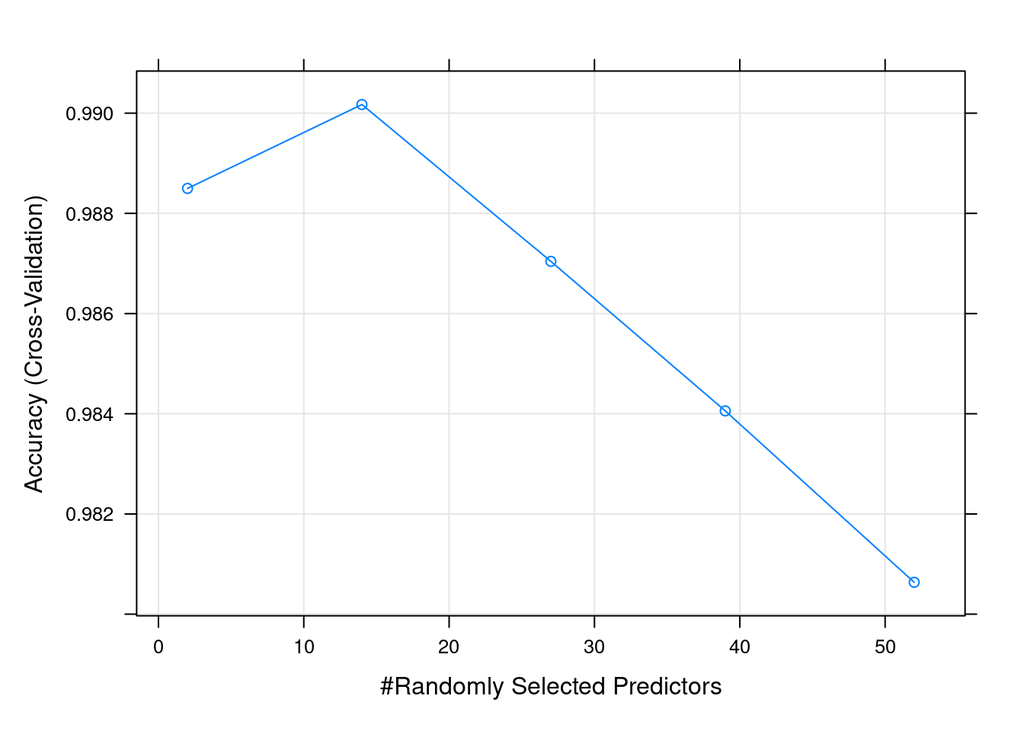

```r
plot(rf)
```

### Figure 3: Gradient boosted trees

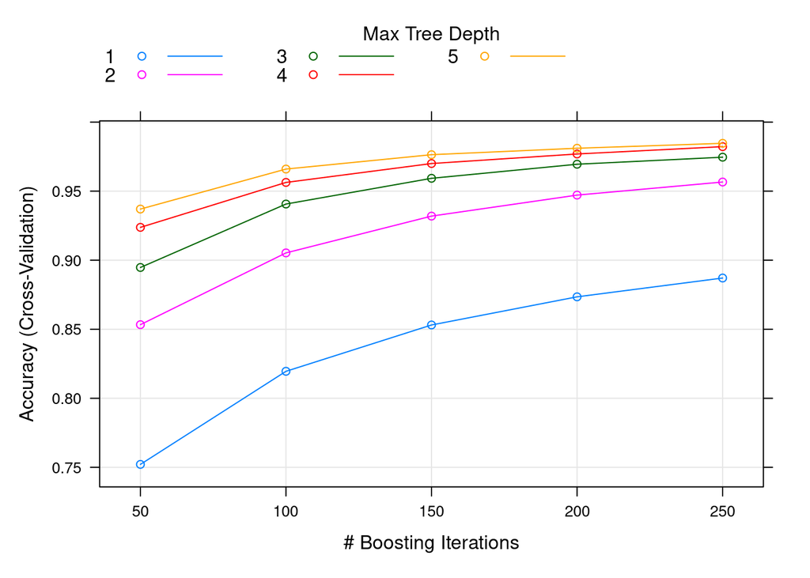

```r
plot(gd_trees)
```